# Exploratory Data Analysis Report

Report by dlookr package

2019-09-13

# 1 Introduction

The EDA Report provides exploratory data analysis information on objects that inherit data.frame and data.frame.

## 1.1 Information of Dataset

The dataset that generated the EDA Report is an **‘data.frame’** object. It consists of **41,336 observations** and **28 variables**.

## 1.2 Information of Variables

The variable information of the data set that generated the EDA Report is shown in the following table.:

Information of Variables

| variables | types | missing_count | missing_percent | unique_count | unique_rate |
| --- | --- | --- | --- | --- | --- |
| id | character | 0 | 0 | 41336 | 1.0000000 |
| creditpolicy | character | 0 | 0 | 2 | 0.0000484 |
| loanamnt | integer | 0 | 0 | 893 | 0.0216034 |
| term | character | 0 | 0 | 2 | 0.0000484 |
| intrate | numeric | 0 | 0 | 394 | 0.0095316 |
| installment | numeric | 0 | 0 | 16190 | 0.3916683 |
| grade | character | 0 | 0 | 7 | 0.0001693 |
| emplength | numeric | 0 | 0 | 11 | 0.0002661 |
| homeownership | character | 0 | 0 | 5 | 0.0001210 |
| annualinc | numeric | 0 | 0 | 5369 | 0.1298868 |
| verificationstatus | character | 0 | 0 | 3 | 0.0000726 |
| targetloanstatus | character | 0 | 0 | 2 | 0.0000484 |
| purpose | character | 0 | 0 | 14 | 0.0003387 |
| dti | numeric | 0 | 0 | 2891 | 0.0699390 |
| delinq2yrs | integer | 0 | 0 | 12 | 0.0002903 |
| inqlast6mths | integer | 0 | 0 | 28 | 0.0006774 |
| openacc | integer | 0 | 0 | 44 | 0.0010644 |
| revolbal | integer | 0 | 0 | 22437 | 0.5427956 |
| revolutil | numeric | 0 | 0 | 1024 | 0.0247726 |
| totalacc | integer | 0 | 0 | 83 | 0.0020079 |
| emp10years | character | 0 | 0 | 2 | 0.0000484 |
| delin2years | character | 0 | 0 | 2 | 0.0000484 |
| homeowner | character | 0 | 0 | 2 | 0.0000484 |
| annualinc_bin | character | 0 | 0 | 5 | 0.0001210 |
| revolbal_bin | character | 0 | 0 | 5 | 0.0001210 |
| verified | character | 0 | 0 | 2 | 0.0000484 |
| purpose_mod | character | 0 | 0 | 7 | 0.0001693 |
| annualinc_bin2 | optimal_bins | 0 | 0 | 3 | 0.0000726 |

The target variable of the data is **‘targetloanstatus’**, and the data type of the variable is **character**.

## 1.3 About EDA Report

EDA reports provide information and visualization results that support the EDA process. In particular, it provides a variety of information to understand the relationship between the target variable and the rest of the variables of interest.

# 2 Univariate Analysis

## 2.1 Descriptive Statistics

edaData  
28 Variables 41336 Observations

id

| n | missing | distinct |
| --- | --- | --- |
| 41336 | 0 | 41336 |

lowest : Arbt001 Arbt002 Arbt003 Arbt004 Arbt005 , highest: Arbt9994 Arbt9995 Arbt9996 Arbt9997 Arbt9998

creditpolicy

| n | missing | distinct |
| --- | --- | --- |
| 41336 | 0 | 2 |

```
 Value          N     Y
 Frequency   2675 38661
 Proportion 0.065 0.935
```

loanamnt

| n | missing | distinct | Info | Mean | Gmd | .05 | .10 | .25 | .50 | .75 | .90 | .95 |
| --- | --- | --- | --- | --- | --- | --- | --- | --- | --- | --- | --- | --- |
| 41336 | 0 | 893 | 0.999 | 11172 | 8058 | 2400 | 3200 | 5400 | 10000 | 15000 | 22000 | 25000 |

lowest : 500 550 600 700 725 , highest: 34475 34525 34675 34800 35000

term

| n | missing | distinct |
| --- | --- | --- |
| 41336 | 0 | 2 |

```
 Value      36months 60months
 Frequency     30616    10720
 Proportion    0.741    0.259
```

intrate

| n | missing | distinct | Info | Mean | Gmd | .05 | .10 | .25 | .50 | .75 | .90 | .95 |
| --- | --- | --- | --- | --- | --- | --- | --- | --- | --- | --- | --- | --- |
| 41336 | 0 | 394 | 1 | 0.1219 | 0.04211 | 0.0654 | 0.0729 | 0.0963 | 0.1199 | 0.1474 | 0.1714 | 0.1862 |

lowest : 0.0542 0.0579 0.0599 0.0600 0.0603 , highest: 0.2359 0.2391 0.2411 0.2440 0.2459

installment

| n | missing | distinct | Info | Mean | Gmd | .05 | .10 | .25 | .50 | .75 | .90 | .95 |
| --- | --- | --- | --- | --- | --- | --- | --- | --- | --- | --- | --- | --- |
| 41336 | 0 | 16190 | 1 | 325.1 | 226.5 | 71.55 | 99.72 | 167.34 | 280.26 | 431.71 | 625.63 | 767.67 |

lowest : 15.67 15.69 15.75 15.76 15.91 , highest: 1283.50 1288.10 1295.21 1302.69 1305.19

grade

| n | missing | distinct |
| --- | --- | --- |
| 41336 | 0 | 7 |

```
 Value          A     B     C     D     E     F     G
 Frequency   9778 12032  8539  5876  3331  1273   507
 Proportion 0.237 0.291 0.207 0.142 0.081 0.031 0.012
```

emplength

| n | missing | distinct | Info | Mean | Gmd | .05 | .10 | .25 | .50 | .75 | .90 | .95 |
| --- | --- | --- | --- | --- | --- | --- | --- | --- | --- | --- | --- | --- |
| 41336 | 0 | 11 | 0.982 | 4.928 | 4.053 | 0 | 0 | 2 | 4 | 9 | 10 | 10 |

```
 Value          0     1     2     3     4     5     6     7     8     9    10
 Frequency   5029  3584  4736  4358  3640  3453  2371  1872  1589  1339  9365
 Proportion 0.122 0.087 0.115 0.105 0.088 0.084 0.057 0.045 0.038 0.032 0.227
```

homeownership

| n | missing | distinct |
| --- | --- | --- |
| 41336 | 0 | 5 |

```
 Value      MORTGAGE     NONE    OTHER      OWN     RENT
 Frequency     18475        4      134     3022    19701
 Proportion    0.447    0.000    0.003    0.073    0.477
```

annualinc

| n | missing | distinct | Info | Mean | Gmd | .05 | .10 | .25 | .50 | .75 | .90 | .95 |
| --- | --- | --- | --- | --- | --- | --- | --- | --- | --- | --- | --- | --- |
| 41336 | 0 | 5369 | 1 | 69789 | 44104 | 24000 | 30000 | 41000 | 60000 | 83500 | 118000 | 145000 |

lowest : 1896 2000 3300 3500 3600 , highest: 1782000 1900000 2039784 3900000 6000000

verificationstatus

| n | missing | distinct |
| --- | --- | --- |
| 41336 | 0 | 3 |

```
 Value         Not Verified Source Verified        Verified
 Frequency            18247           10094           12995
 Proportion           0.441           0.244           0.314
```

targetloanstatus

| n | missing | distinct |
| --- | --- | --- |
| 41336 | 0 | 2 |

```
 Value         Default No_Default
 Frequency        6165      35171
 Proportion      0.149      0.851
```

purpose

| n | missing | distinct |
| --- | --- | --- |
| 41336 | 0 | 14 |

car (1559, 0.038), credit_card (5341, 0.129), debt_consolidation (19347, 0.468), educational (410, 0.010), home_improvement (3096, 0.075), house (411, 0.010), major_purchase (2231, 0.054), medical (724, 0.018), moving (600, 0.015), other (4217, 0.102), renewable_energy (98, 0.002), small_business (1945, 0.047), vacation (367, 0.009), wedding (990, 0.024)

dti

| n | missing | distinct | Info | Mean | Gmd | .05 | .10 | .25 | .50 | .75 | .90 | .95 |
| --- | --- | --- | --- | --- | --- | --- | --- | --- | --- | --- | --- | --- |
| 41336 | 0 | 2891 | 1 | 13.39 | 7.72 | 2.13 | 4.08 | 8.22 | 13.49 | 18.68 | 22.43 | 23.92 |

lowest : 0.00 0.01 0.02 0.03 0.04 , highest: 29.92 29.93 29.95 29.96 29.99

delinq2yrs

| n | missing | distinct | Info | Mean | Gmd | .05 | .10 | .25 | .50 | .75 | .90 | .95 |
| --- | --- | --- | --- | --- | --- | --- | --- | --- | --- | --- | --- | --- |
| 41336 | 0 | 12 | 0.299 | 0.153 | 0.2794 | 0 | 0 | 0 | 0 | 0 | 1 | 1 |

```
 Value          0     1     2     3     4     5     6     7     8     9    11    13
 Frequency  36713  3513   750   238    70    26    13     6     3     1     2     1
 Proportion 0.888 0.085 0.018 0.006 0.002 0.001 0.000 0.000 0.000 0.000 0.000 0.000
```

inqlast6mths

| n | missing | distinct | Info | Mean | Gmd | .05 | .10 | .25 | .50 | .75 | .90 | .95 |
| --- | --- | --- | --- | --- | --- | --- | --- | --- | --- | --- | --- | --- |
| 41336 | 0 | 28 | 0.88 | 1.084 | 1.395 | 0 | 0 | 0 | 1 | 2 | 3 | 4 |

lowest : 0 1 2 3 4 , highest: 27 28 31 32 33

openacc

| n | missing | distinct | Info | Mean | Gmd | .05 | .10 | .25 | .50 | .75 | .90 | .95 |
| --- | --- | --- | --- | --- | --- | --- | --- | --- | --- | --- | --- | --- |
| 41336 | 0 | 44 | 0.994 | 9.373 | 4.888 | 3 | 4 | 6 | 9 | 12 | 15 | 18 |

lowest : 1 2 3 4 5 , highest: 41 42 44 46 47

revolbal

| n | missing | distinct | Info | Mean | Gmd | .05 | .10 | .25 | .50 | .75 | .90 | .95 |
| --- | --- | --- | --- | --- | --- | --- | --- | --- | --- | --- | --- | --- |
| 41336 | 0 | 22437 | 1 | 14410 | 16062 | 324 | 1100 | 3702 | 8932 | 17381 | 30457 | 44748 |

lowest : 0 1 2 3 4 , highest: 487589 508961 602519 952013 1207359

revolutil

| n | missing | distinct | Info | Mean | Gmd | .05 | .10 | .25 | .50 | .75 | .90 | .95 |
| --- | --- | --- | --- | --- | --- | --- | --- | --- | --- | --- | --- | --- |
| 41336 | 0 | 1024 | 1 | 0.4928 | 0.327 | 0.027 | 0.088 | 0.260 | 0.499 | 0.729 | 0.881 | 0.937 |

lowest : 0.000 0.001 0.002 0.003 0.004 , highest: 1.062 1.064 1.065 1.088 1.190

totalacc

| n | missing | distinct | Info | Mean | Gmd | .05 | .10 | .25 | .50 | .75 | .90 | .95 |
| --- | --- | --- | --- | --- | --- | --- | --- | --- | --- | --- | --- | --- |
| 41336 | 0 | 83 | 0.999 | 22.17 | 12.83 | 6.75 | 9.00 | 13.00 | 20.00 | 29.00 | 38.00 | 44.00 |

lowest : 1 2 3 4 5 , highest: 79 80 81 87 90

emp10years

| n | missing | distinct |
| --- | --- | --- |
| 41336 | 0 | 2 |

```
 Value          N     Y
 Frequency  31971  9365
 Proportion 0.773 0.227
```

delin2years

| n | missing | distinct |
| --- | --- | --- |
| 41336 | 0 | 2 |

```
 Value          N     Y
 Frequency  36713  4623
 Proportion 0.888 0.112
```

homeowner

| n | missing | distinct |
| --- | --- | --- |
| 41336 | 0 | 2 |

```
 Value          N     Y
 Frequency  19839 21497
 Proportion  0.48  0.52
```

annualinc_bin

| n | missing | distinct |
| --- | --- | --- |
| 41336 | 0 | 5 |

```
 Value        Gp1   Gp2   Gp3   Gp4   Gp5
 Frequency   8387  8251  8177  8266  8255
 Proportion 0.203 0.200 0.198 0.200 0.200
```

revolbal_bin

| n | missing | distinct |
| --- | --- | --- |
| 41336 | 0 | 5 |

```
 Value       Gp1  Gp2  Gp3  Gp4  Gp5
 Frequency  8268 8267 8268 8266 8267
 Proportion  0.2  0.2  0.2  0.2  0.2
```

verified

| n | missing | distinct |
| --- | --- | --- |
| 41336 | 0 | 2 |

```
 Value          N     Y
 Frequency  18247 23089
 Proportion 0.441 0.559
```

purpose_mod

| n | missing | distinct |
| --- | --- | --- |
| 41336 | 0 | 7 |

```
 Value                business                car        credit_card
 Frequency                2043               1559               5341
 Proportion              0.049              0.038              0.129

 Value      debt_consolidation    living_expenses             luxury
 Frequency               19347               6231               2598
 Proportion              0.468              0.151              0.063

 Value                   other
 Frequency                4217
 Proportion              0.102
```

annualinc_bin2

| n | missing | distinct |
| --- | --- | --- |
| 41336 | 0 | 3 |

```
 Value      [1.9e+03,3.67e+04]   (3.67e+04,6e+04]      (6e+04,6e+06]
 Frequency                7716              14395              19225
 Proportion              0.187              0.348              0.465
```

## 2.2 Normality Test of Numerical Variables

### 2.2.1 Statistics and Visualization of (Sample) Data

**[ loanamnt ]**

normality test : Shapiro-Wilk normality test

```
 statistic : 0.91531,  p-value : 1.86998E-46
```

skewness and kurtosis

| type | skewness | kurtosis |
| --- | --- | --- |
| original | 1.0127927 | 3.576839 |
| log transformation | -0.5147467 | 3.008385 |
| sqrt transformation | 0.3271385 | 2.518269 |

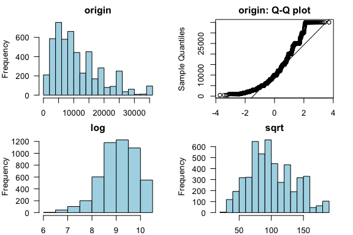

**[ intrate ]**

normality test : Shapiro-Wilk normality test

```
 statistic : 0.98491,  p-value : 1.04314E-22
```

skewness and kurtosis

| type | skewness | kurtosis |
| --- | --- | --- |
| original | 0.2403885 | 2.553981 |
| log transformation | -0.4121948 | 2.499608 |
| sqrt transformation | -0.0889756 | 2.393635 |

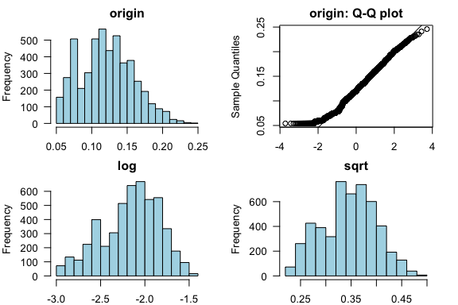

**[ installment ]**

normality test : Shapiro-Wilk normality test

```
 statistic : 0.92473,  p-value : 1.50367E-44
```

skewness and kurtosis

| type | skewness | kurtosis |
| --- | --- | --- |
| original | 1.0372332 | 3.908589 |
| log transformation | -0.5117729 | 3.003085 |
| sqrt transformation | 0.3146528 | 2.612469 |

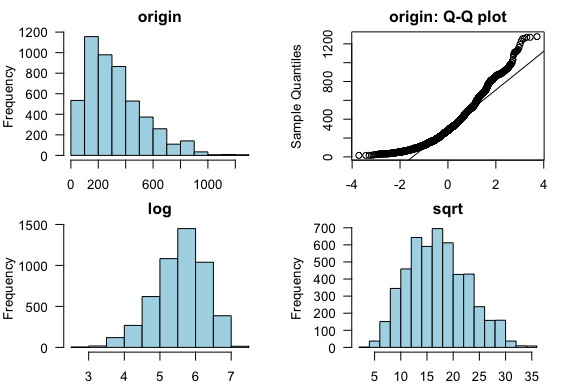

**[ emplength ]**

normality test : Shapiro-Wilk normality test

```
 statistic : 0.8869,  p-value : 2.64586E-51
```

skewness and kurtosis

| type | skewness | kurtosis |
| --- | --- | --- |
| original | 0.1925179 | 1.618139 |
| log transformation | NaN | NaN |
| sqrt transformation | -0.5806064 | 2.348432 |

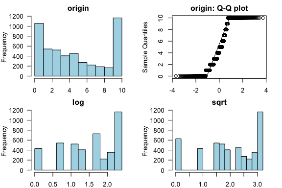

**[ annualinc ]**

normality test : Shapiro-Wilk normality test

```
 statistic : 0.59818,  p-value : 1.70855E-75
```

skewness and kurtosis

| type | skewness | kurtosis |
| --- | --- | --- |
| original | 7.5354867 | 118.831985 |
| log transformation | 0.1839649 | 4.254818 |
| sqrt transformation | 2.0848364 | 15.482657 |

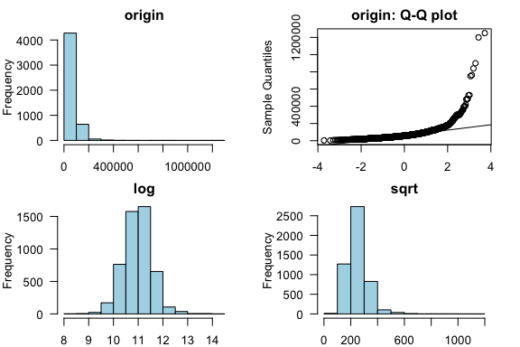

**[ dti ]**

normality test : Shapiro-Wilk normality test

```
 statistic : 0.98506,  p-value : 1.34929E-22
```

skewness and kurtosis

| type | skewness | kurtosis |
| --- | --- | --- |
| original | -0.0257835 | 2.204066 |
| log transformation | NaN | NaN |
| sqrt transformation | -0.7603983 | 3.267578 |

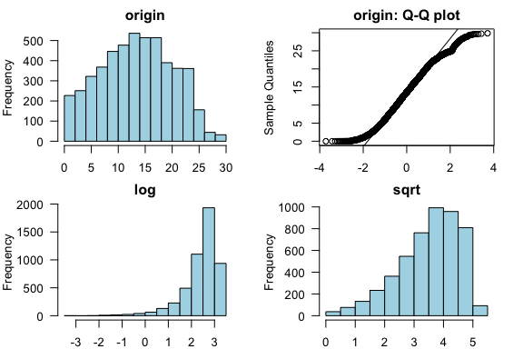

**[ delinq2yrs ]**

normality test : Shapiro-Wilk normality test

```
 statistic : 0.32984,  p-value : 1.30685E-86
```

skewness and kurtosis

| type | skewness | kurtosis |
| --- | --- | --- |
| original | 5.608910 | 60.19585 |
| log transformation | NaN | NaN |
| sqrt transformation | 2.842261 | 10.58496 |

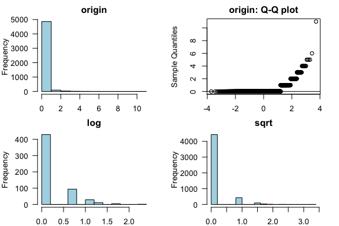

**[ inqlast6mths ]**

normality test : Shapiro-Wilk normality test

```
 statistic : 0.68231,  p-value : 1.19306E-70
```

skewness and kurtosis

| type | skewness | kurtosis |
| --- | --- | --- |
| original | 3.9004249 | 49.796418 |
| log transformation | NaN | NaN |
| sqrt transformation | 0.5631318 | 2.680525 |

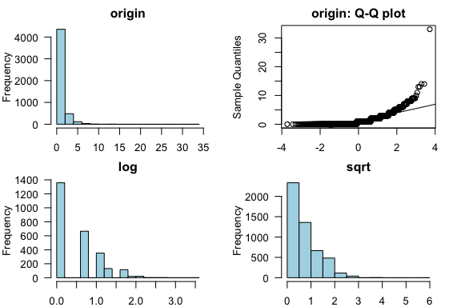

**[ openacc ]**

normality test : Shapiro-Wilk normality test

```
 statistic : 0.9348,  p-value : 2.75409E-42
```

skewness and kurtosis

| type | skewness | kurtosis |
| --- | --- | --- |
| original | 1.1265525 | 5.688742 |
| log transformation | -0.3408913 | 3.050905 |
| sqrt transformation | 0.3563253 | 3.175351 |

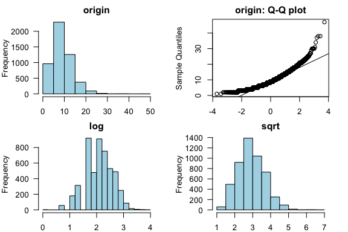

**[ revolbal ]**

normality test : Shapiro-Wilk normality test

```
 statistic : 0.58389,  p-value : 3.14839E-76
```

skewness and kurtosis

| type | skewness | kurtosis |
| --- | --- | --- |
| original | 4.988450 | 43.152568 |
| log transformation | NaN | NaN |
| sqrt transformation | 1.427517 | 7.379429 |

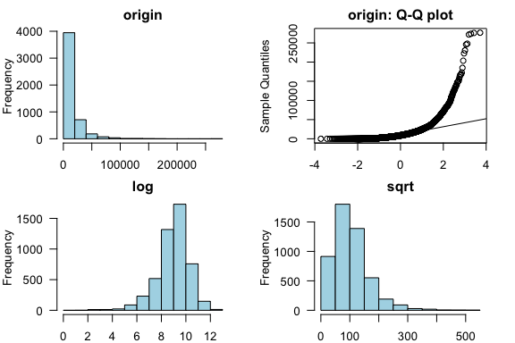

**[ revolutil ]**

normality test : Shapiro-Wilk normality test

```
 statistic : 0.9637,  p-value : 1.09836E-33
```

skewness and kurtosis

| type | skewness | kurtosis |
| --- | --- | --- |
| original | -0.0437215 | 1.912142 |
| log transformation | NaN | NaN |
| sqrt transformation | -0.8115736 | 3.013100 |

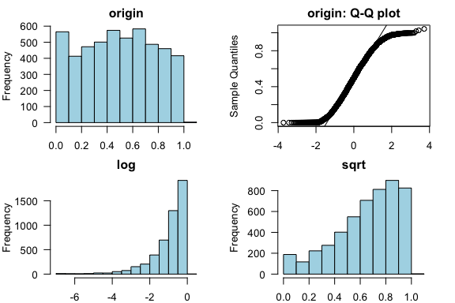

**[ totalacc ]**

normality test : Shapiro-Wilk normality test

```
 statistic : 0.9541,  p-value : 5.21929E-37
```

skewness and kurtosis

| type | skewness | kurtosis |
| --- | --- | --- |
| original | 0.8370624 | 3.680342 |
| log transformation | -0.6573022 | 3.655376 |
| sqrt transformation | 0.1526075 | 2.719729 |

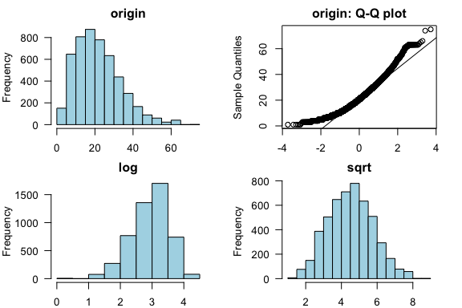

# 3 Relationship Between Variables

## 3.1 Correlation Coefficient

### 3.1.1 Correlation Coefficient by Variable Combination

Table of correlation coefficients (0.5 or more)

| Variable1 | Variable2 | Correlation Coefficient |
| --- | --- | --- |
| installment | loanamnt | 0.9302521 |
| totalacc | openacc | 0.6918625 |

### 3.1.2 Correlation Plot of Numerical Variables

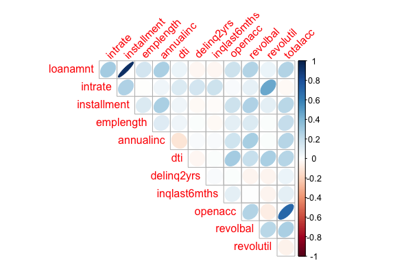

# 4 Target based Analysis